# Butte Creek

Sadie Gill, Mark Tompkins

July 2020

## Future Data Improvements

None planned.

## Instream Spawning and Rearing Habiat

**Data Source:** [FWS 2003](https://cvpiahabitat-r-package.s3.us-west-2.amazonaws.com/Butte_Creek_Spring-run_chinook_salmon_spawning_8-29-2003.pdf) (77-78) and [FERC relicensing of DeSabla](https://s3-us-west-2.amazonaws.com/cvpiahabitat-r-package/cvpia-sit-model-inputs/DeSabla2008ButteIFIM.pdf) (APPENDIX E6.3.2.6-J1)

Instream spawning and rearing habitat in Butte Creek is based on data from the FWS instream 2003 study and the FERC relicensing of DeSabla 2008 study. Spawning habitat data are from the FWS study (p. 77-78). For Spring Run only, spawning data were generated using a RIVER2D 2-dimensional hydraulic and habitat model. The spawning data were compiled in a spreadsheet and scaled by reach length. The rearing data come from DeSabla 2008 in the lower butte section of the appendix (APPENDIX E6.3.2.6-J1). Instream rearing habitat data were provided in a [spreadsheet](https://cvpiahabitat-r-package.s3-us-west-2.amazonaws.com/IFIMWUA.xlsx). Mark Gard instructed us to use cells A71:C101 for the Fall Run Chinook rearing data. Units are in square feet per 1000 feet.

### Spawning Data

#### Spring Run

Header Descriptions: flow_cfs = flow in cubic feet per second, SR_spawn_wua = Spring Run Chinook Spawning WUA, watershed = section of stream modeled for CVPIA SDM

| flow_cfs | SR_spawn_wua | watershed |
| --- | --- | --- |
| 20 | 656.4146 | Butte Creek |
| 25 | 662.8812 | Butte Creek |
| 30 | 669.0249 | Butte Creek |
| 35 | 680.7027 | Butte Creek |
| 40 | 685.0326 | Butte Creek |

*… with 36 more rows*

#### Steelhead

Header Descriptions: flow_cfs = flow in cubic feet per second, ST_spawn_wua = Steelhead Spawning WUA, watershed = section of stream modeled for CVPIA SDM

| flow_cfs | ST_spawn_wua | watershed |
| --- | --- | --- |
| 60 | 3647 | Butte Creek |
| 70 | 4139 | Butte Creek |
| 80 | 4480 | Butte Creek |
| 90 | 4889 | Butte Creek |
| 100 | 5137 | Butte Creek |

*… with 25 more rows*

### Rearing Data

Header Descriptions: flow_cfs = flow in cubic feet per second, SR_fry_wua = Spring Run Chinook Fry WUA, SR_juv_wua = Spring Run Chinook Juvenile WUA, ST_adult_wua = Steelhead Adult WUA, watershed = section of stream modeled for CVPIA SDM

| flow_cfs | SR_fry_wua | SR_juv_wua | ST_adult_wua | watershed |
| --- | --- | --- | --- | --- |
| 60 | 17549 | 18472 | 14399 | Butte Creek |
| 70 | 16339 | 19560 | 15950 | Butte Creek |
| 80 | 15208 | 20259 | 17296 | Butte Creek |
| 90 | 14391 | 20632 | 18265 | Butte Creek |
| 100 | 13426 | 20894 | 19367 | Butte Creek |

*… with 25 more rows*

### Spawning WUA

The following plot shows the weighted usable spawning area (WUA) in square feet per thousand feet for Spring Run Chinook Salmon. These area per length rates are multiplied by the total spawning reach length mapped by the Science Integration Team (SIT) to estimate available habitat.

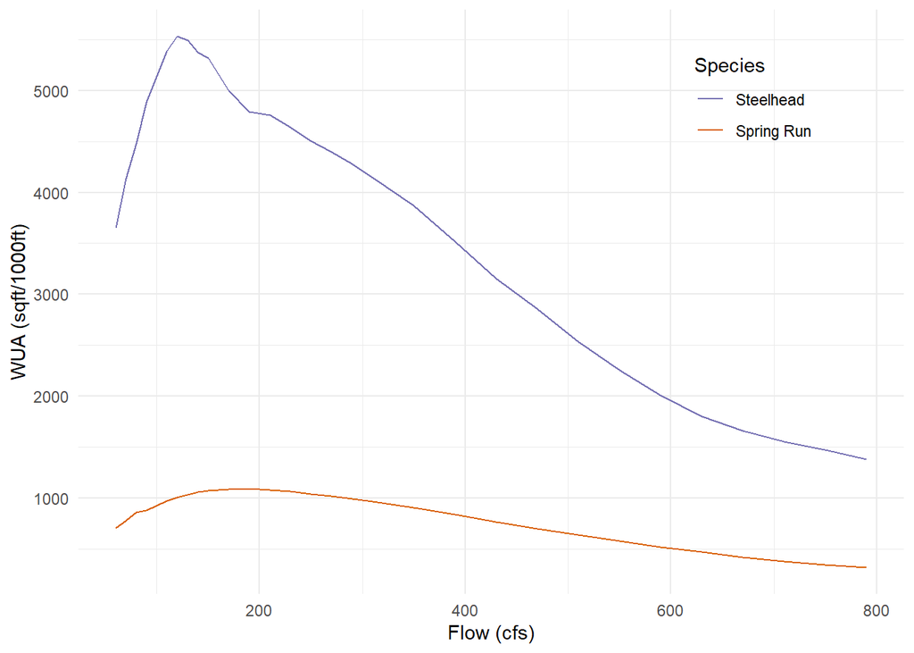

### Rearing WUA

The following plot shows the rearing WUA in square feet per thousand feet for Spring Run Chinook Salmon fry and juvenile. These rates are multiplied by the total rearing reach length mapped by the SIT to estimate available habitat.

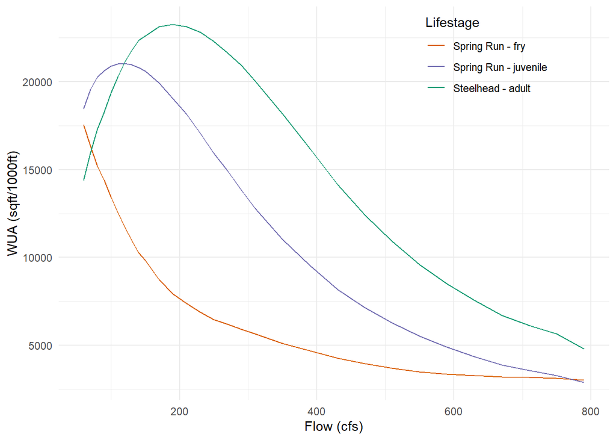

## Floodplain Rearing Habitat

**Data Source:** [Central Valley Floodplain Evaluation and Delineation (CVFED) HEC-RAS hydraulic model](https://s3-us-west-2.amazonaws.com/cvpiahabitat-r-package/cvpia-sit-model-inputs/CombinedTM_IQAR_Final-FULL-REPORT_20140206.pdf)

### Fall Run

A 17.1 mile portion of the entire mapped rearing extent of 17.1 miles was modeled using Central Valley Floodplain Evaluation and Delineation (CVFED) HEC-RAS hydraulic model. Of the entire mapped rearing extent, 17.1 miles were classified as low gradient and 0 miles were classified as high gradient based on a geomorphic analysis of long profile slopes and valley widths. The floodplain area per unit length was determined for the modeled extent and used to approximate areas for the non-modeled extent. The area per unit length was scaled by a factor of 0.1 for the high gradient extent. There was no scaling factor applied to the low gradient extent.

### Spring Run and Steelhead

A 17.1 mile portion of the entire mapped rearing extent of 31.7 miles was modeled using Central Valley Floodplain Evaluation and Delineation (CVFED) HEC-RAS hydraulic model. Of the entire mapped rearing extent, 17.1 miles were classified as low gradient and 14.6 miles were classified as high gradient based on a geomorphic analysis of long profile slopes and valley widths. The floodplain area per unit length was determined for the modeled extent and used to approximate areas for the non-modeled extent. The area per unit length was scaled by a factor of 0.1 for the high gradient extent. There was no scaling factor applied to the low gradient extent.

## Floodplain Data

The areas represent total inundated area in acres.

Header Descriptions: flow_cfs = flow in cubic feet per second, FR_floodplain_acres = Fall Run Chinook floodplain acres, SR_floodplain_acres = Spring Run Chinook floodplain acres, ST_floodplain_acres = Steelhead floodplain acres, watershed = section of stream modeled for CVPIA SDM

| flow_cfs | FR_floodplain_acres | SR_floodplain_acres | ST_floodplain_acres | watershed |
| --- | --- | --- | --- | --- |
| 310 | 0.00 | 0.00 | 0.00 | Butte Creek |
| 410 | 19.61 | 21.27 | 21.27 | Butte Creek |
| 450 | 31.27 | 33.92 | 33.92 | Butte Creek |
| 510 | 48.76 | 52.89 | 52.89 | Butte Creek |
| 610 | 74.51 | 80.82 | 80.82 | Butte Creek |

*… with 23 more rows*

## Floodplain Plot

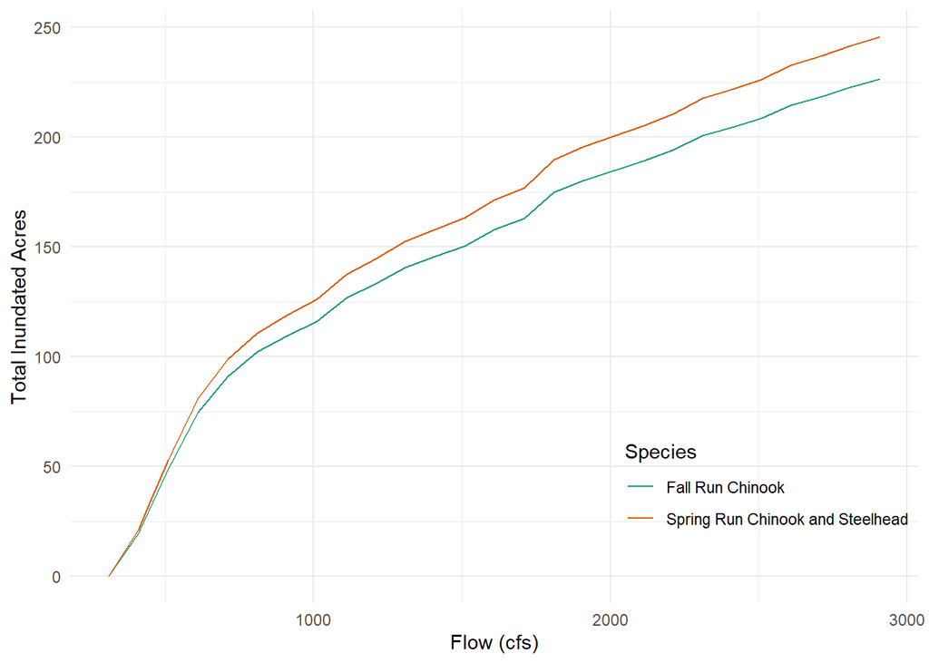